# individual2

Adam Ford

9/8/2020

## Adam’s Individual Analysis

```r
choco <- read.csv("https://raw.githubusercontent.com/xdaiISU/ds202materials/master/hwlabs/data/choco.csv")
str(choco)
```

```
## 'data.frame':    2312 obs. of  13 variables:
##  $ REF                 : int  2454 2458 2454 797 797 1015 1019 1011 1019 1011 ...
##  $ Company             : chr  "5150" "5150" "5150" "A. Morin" ...
##  $ Location            : chr  "U.S.A." "U.S.A." "U.S.A." "France" ...
##  $ Date                : int  2019 2019 2019 2012 2012 2013 2013 2013 2013 2013 ...
##  $ Bean_Origin         : chr  "Madagascar" "Dominican Republic" "Tanzania" "Peru" ...
##  $ Specific_Bean_Origin: chr  "Bejofo Estate, batch 1" "Zorzal, batch 1" "Kokoa Kamili, batch 1" "Peru" ...
##  $ Cocoa_Percent       : num  76 76 76 63 70 70 63 70 70 70 ...
##  $ Ingredients         : chr  "3- B,S,C" "3- B,S,C" "3- B,S,C" "4- B,S,C,L" ...
##  $ Characteristics1    : chr  "cocoa" "cocoa" "rich cocoa" "fruity" ...
##  $ Characteristics2    : chr  "blackberry" "vegetal" "fatty" "melon" ...
##  $ Characteristics3    : chr  "full body" "savory" "bready" "roasty" ...
##  $ Characteristics4    : chr  NA NA NA NA ...
##  $ Rating              : num  3.75 3.5 3.25 3.75 3.5 4 4 3.75 3.5 3.25 ...
```

```r
summary(choco)
```

```
##       REF         Company            Location              Date
##  Min.   :   5   Length:2312        Length:2312        Min.   :2006
##  1st Qu.: 741   Class :character   Class :character   1st Qu.:2011
##  Median :1351   Mode  :character   Mode  :character   Median :2014
##  Mean   :1318                                         Mean   :2014
##  3rd Qu.:1912                                         3rd Qu.:2016
##  Max.   :2490                                         Max.   :2020
##  Bean_Origin        Specific_Bean_Origin Cocoa_Percent    Ingredients
##  Length:2312        Length:2312          Min.   : 42.00   Length:2312
##  Class :character   Class :character     1st Qu.: 70.00   Class :character
##  Mode  :character   Mode  :character     Median : 70.00   Mode  :character
##                                          Mean   : 71.65
##                                          3rd Qu.: 75.00
##                                          Max.   :100.00
##  Characteristics1   Characteristics2   Characteristics3   Characteristics4
##  Length:2312        Length:2312        Length:2312        Length:2312
##  Class :character   Class :character   Class :character   Class :character
##  Mode  :character   Mode  :character   Mode  :character   Mode  :character
##
##
##
##      Rating
##  Min.   :1.000
##  1st Qu.:3.000
##  Median :3.250
##  Mean   :3.184
##  3rd Qu.:3.500
##  Max.   :4.000
```

## 1

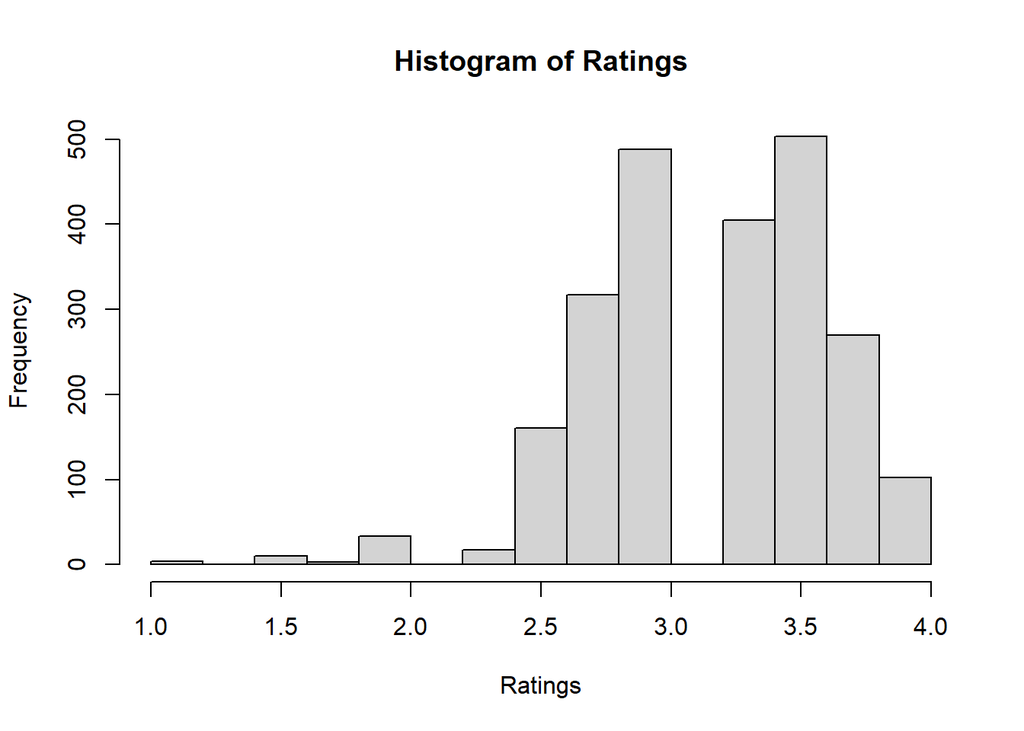

```r
Ratings <- choco$Rating
hist(Ratings)
```

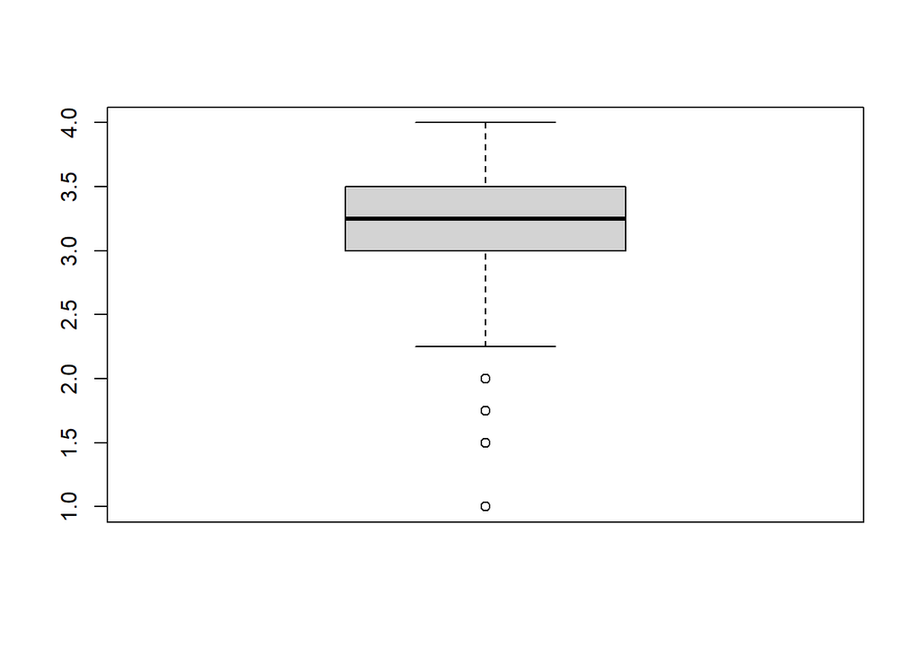

```r
boxplot(Ratings)
```

This histogram shows that most the ratings fall between 2.5 and 4.0, but have no ratings between 3.0 and 3.2. The histogram also starts to give us an idea that there may be outliers in the lower ratings. However, the boxplot can confirm this. The ratings at 1.0, 1.5, 1.75, and 2.0 are outliers. Also we see the median at approximately 3.25 an an IQR of .5.

## 2

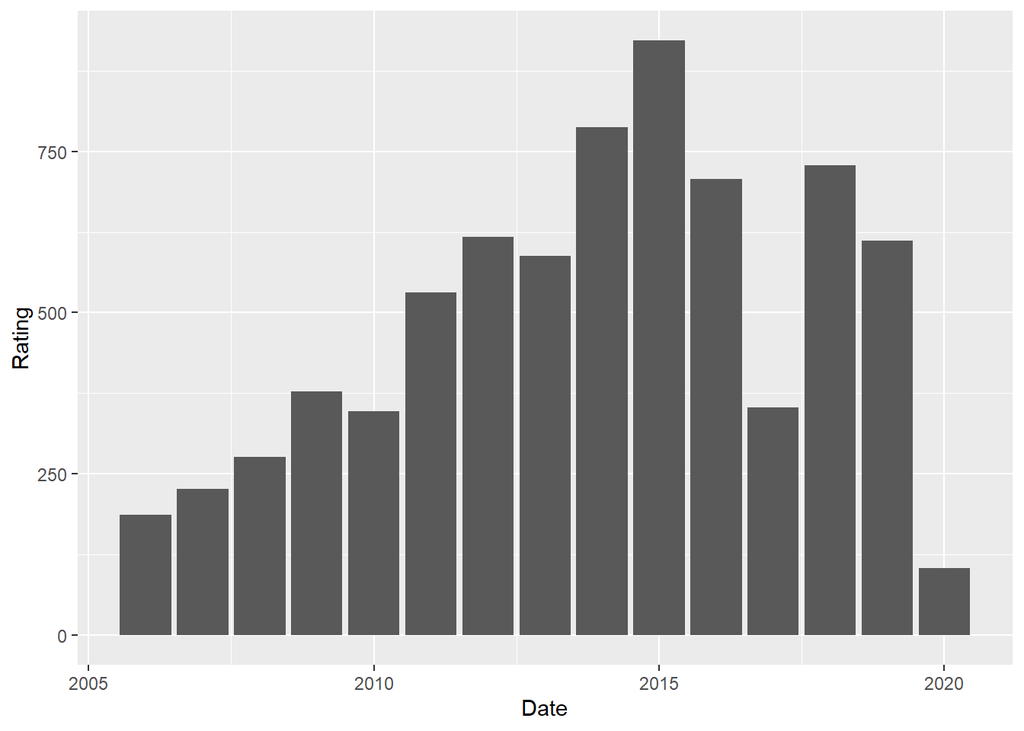

```r
library(ggplot2)
ggplot(choco, aes(x=Date, y=Rating)) + geom_bar(stat = "identity")
```

This graph shows how many ratings were included by year. He started in 2006 and generally reviewed more and more chocolate each year until 2015, this is where he peaked and began to review less consistently.

## 3

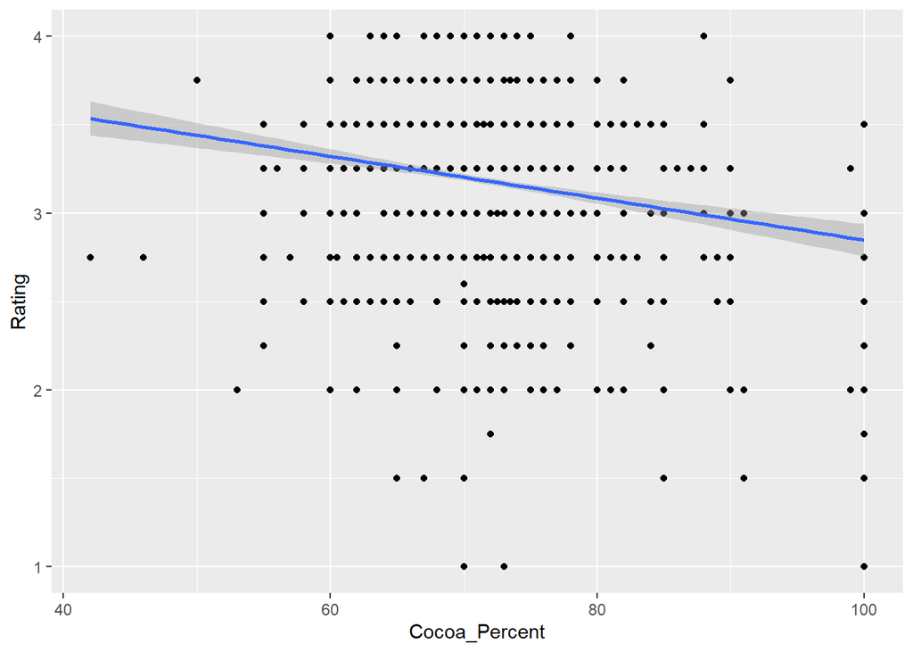

```r
ggplot(choco, aes(x=Cocoa_Percent, y=Rating)) + geom_point() + geom_smooth(method=lm, formula= y~x)
```

```r
summary(choco$Cocoa_Percent)
```

```
##    Min. 1st Qu.  Median    Mean 3rd Qu.    Max.
##   42.00   70.00   70.00   71.65   75.00  100.00
```

```r
bottomHalf <- choco[choco$Cocoa_Percent < 70,]
topHalf <- choco[choco$Cocoa_Percent >= 70,]
summary(bottomHalf$Rating)
```

```
##    Min. 1st Qu.  Median    Mean 3rd Qu.    Max.
##   1.500   3.000   3.250   3.189   3.500   4.000
```

```r
summary(topHalf$Rating)
```

```
##    Min. 1st Qu.  Median    Mean 3rd Qu.    Max.
##   1.000   3.000   3.250   3.183   3.500   4.000
```

The graphical summary of the relationship between the Cocoa Percentage and the Rating doesn’t show a very clear relationships in the points themselves. However, the trendline does show a slight negative correlation. To check this numerically I split the data at the median to see how the data summary of the lower half of Cocoa Percentage compared to the top half. This numerical representation shows almost no difference between the two halves, besides a slightly lower mean rating for the chocolate with a higher percentage.

## 4

```r
charac <- c()
for( row in 1:nrow(choco))
{
  charac <- c(charac, choco[row, 'Characteristics1'])
  charac <- c(charac, choco[row, 'Characteristics2'])
  charac <- c(charac, choco[row, 'Characteristics3'])
  cahrac <- c(charac, choco[row, 'Characteristics4'])
}
uniques <- unique(unlist(charac, use.names = FALSE))
means <- c()
for( uniq in uniques)
{
  curr <- choco[(choco$Characteristics1 == uniq) | (choco$Characteristics2 == uniq) | (choco$Characteristics3 == uniq) | (choco$Characteristics4 == uniq),]
  means <- c(means, mean(curr$Rating, na.rm = TRUE))
}
meanByCharac <- data.frame("Characteristic" = uniques, "Mean" = means)
worst5 <- meanByCharac[order(meanByCharac$Mean),]
best5 <- meanByCharac[order(-meanByCharac$Mean),]
head(best5, 5)
```

```
##     Characteristic Mean
## 18       tangerine    4
## 105 intense pepper    4
## 207        rounded    4
## 223    raspberries    4
## 264   gentle roast    4
```

```r
head(worst5, 5)
```

```
##            Characteristic     Mean
## 380 this is not chocolate 1.000000
## 669     strong off flavor 1.000000
## 185           very bitter 1.458333
## 316                klingy 1.500000
## 378 high intensity bitter 1.500000
```

These lists show the mean Rating of the authors favorite and least favorite chocolates based on the characteristic listed.

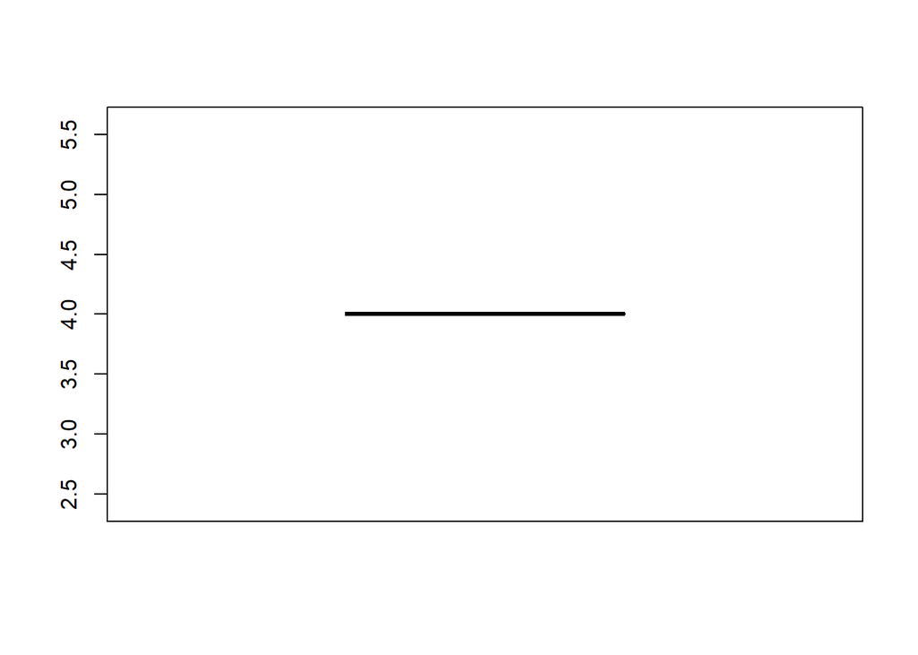

```r
tangerine <- choco[(choco$Characteristics1 == 'tangerine') | (choco$Characteristics2 == 'tangerine') | (choco$Characteristics3 == 'tangerine') | (choco$Characteristics4 == 'tangerine'),]

notChocoloate <- choco[(choco$Characteristics1 == 'this is not chocolate') | (choco$Characteristics2 == 'this is not chocolate') | (choco$Characteristics3 == 'this is not chocolate ') | (choco$Characteristics4 == 'this is not chocolate '),]

boxplot(tangerine$Rating)
```

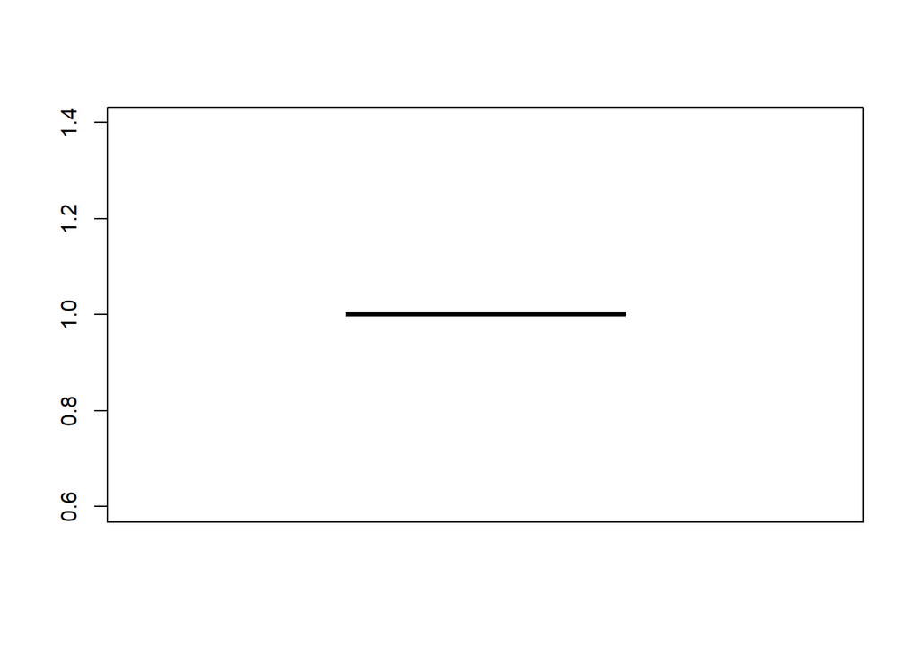

```r
boxplot(notChocoloate$Rating)
```

These graphs show us why some of the characteristics had the highest or lowest mean. It is due to them not having many ratings, often a single very low or very high rating.

## 5

With my partner I hope to find a more meaningful graphical showing of characteristics with high or low means, keeping in better mind the amount of reviews a chocolate has received. This perhaps means eliminating characteristics that have not reached a threshold of number of reviews.

Additionally, I would be curious to see which company is the reviews favorite. Perhaps a boxplot of each companies reviewed chocolate side by side would show this well.